# Example Hands on 2

# Hands-on 2: Key concepts and techniques

## Part I: Key concepts

Before we can start with the exercises we need to load the required packages and the example data we work with:

```r
# load required packages
library(tidyverse)
library(microbiome)

#load data
data(dietswap)
print(dietswap)
```

```
## phyloseq-class experiment-level object
## otu_table()   OTU Table:         [ 130 taxa and 222 samples ]
## sample_data() Sample Data:       [ 222 samples by 8 sample variables ]
## tax_table()   Taxonomy Table:    [ 130 taxa by 3 taxonomic ranks ]
```

```r
# rename the example data
pseq <- dietswap
# transform data for compositional analysis
pseq.rel <- microbiome::transform(pseq, transform = "compositional")
pseq.clr <- microbiome::transform(pseq, transform = "clr")
```

- **Alpha diversity** Estimate taxonomic diversity for each sample (function microbiome::alpha). Compare the results between two or more diversity indices (visually or statistically). See [microbiome tutorial](https://microbiome.github.io/tutorials/) for examples.

```r
tab.alpha <- alpha(pseq)
head(tab.alpha) %>% kable()
```

|  | observed | chao1 | diversity_inverse_simpson | diversity_gini_simpson | diversity_shannon | diversity_fisher | diversity_coverage | evenness_camargo | evenness_pielou | evenness_simpson | evenness_evar | evenness_bulla | dominance_dbp | dominance_dmn | dominance_absolute | dominance_relative | dominance_simpson | dominance_core_abundance | dominance_gini | rarity_log_modulo_skewness | rarity_low_abundance | rarity_rare_abundance |
| --- | --- | --- | --- | --- | --- | --- | --- | --- | --- | --- | --- | --- | --- | --- | --- | --- | --- | --- | --- | --- | --- | --- |
| Sample-1 | 104 | 114.6667 | 7.561722 | 0.8677550 | 2.940698 | 16.69360 | 4 | 0.2014036 | 0.6331719 | 0.0727089 | 0.1709714 | 0.3298916 | 0.3279347 | 0.4297198 | 2774 | 0.3279347 | 0.1322450 | 0.9992907 | 0.8625360 | 2.057691 | 0.0289632 | 0.0000000 |
| Sample-2 | 110 | 121.6364 | 8.102943 | 0.8765881 | 2.822472 | 15.20257 | 3 | 0.2261992 | 0.6004646 | 0.0736631 | 0.1334372 | 0.2755652 | 0.2428626 | 0.4656170 | 5121 | 0.2428626 | 0.1234119 | 0.9994309 | 0.8843695 | 2.057552 | 0.0299725 | 0.0004268 |
| Sample-3 | 103 | 107.5000 | 4.291085 | 0.7669587 | 2.407963 | 13.42077 | 2 | 0.2109176 | 0.5195476 | 0.0416610 | 0.1373098 | 0.2541325 | 0.4594744 | 0.5603989 | 13271 | 0.4594744 | 0.2330413 | 0.9999654 | 0.9083094 | 2.052324 | 0.0339646 | 0.0000000 |
| Sample-4 | 105 | 112.1429 | 7.930799 | 0.8739093 | 2.992482 | 15.56061 | 4 | 0.3422309 | 0.6429969 | 0.0755314 | 0.1711334 | 0.3176017 | 0.3230653 | 0.3957720 | 4279 | 0.3230653 | 0.1260907 | 0.9995470 | 0.8569405 | 2.051175 | 0.0348056 | 0.0002265 |
| Sample-5 | 103 | 110.6818 | 3.170738 | 0.6846160 | 2.106022 | 14.53671 | 1 | 0.1407817 | 0.4544002 | 0.0307839 | 0.1661081 | 0.2310307 | 0.5450144 | 0.6317579 | 9456 | 0.5450144 | 0.3153840 | 0.9998847 | 0.9212609 | 2.059634 | 0.0441499 | 0.0000000 |
| Sample-6 | 105 | 113.9091 | 2.953753 | 0.6614476 | 2.071136 | 14.55619 | 1 | 0.1709221 | 0.4450266 | 0.0281310 | 0.1625409 | 0.2308364 | 0.5693811 | 0.6430163 | 11243 | 0.5693811 | 0.3385524 | 0.9993923 | 0.9192203 | 2.059421 | 0.0375772 | 0.0000506 |

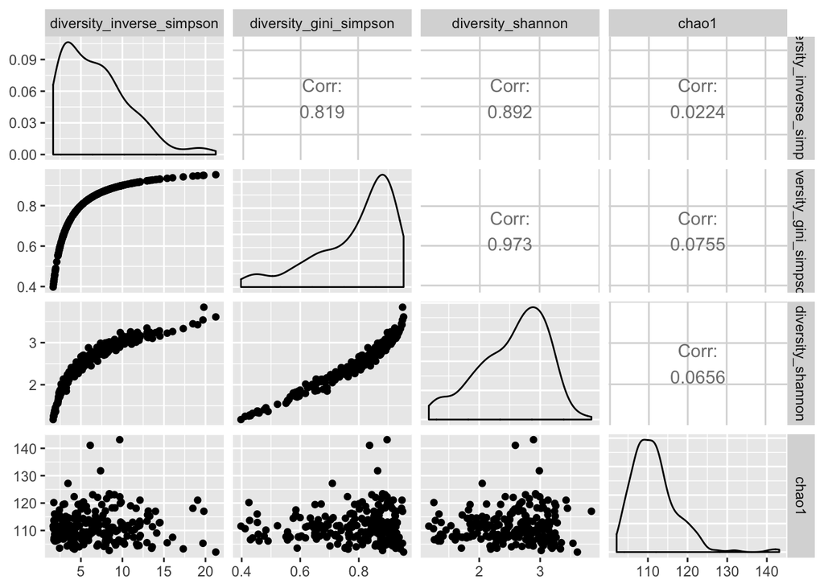

```r
# let us select 3 indeces and see how they correlate:
# I use the function ggpairs from the package GGally, which you
# might need to install first:

if(!require(GGally)) {
  install.packages("GGally")
}

tab.alpha %>%
  select(
    diversity_inverse_simpson,
    diversity_gini_simpson,
    diversity_shannon,
    chao1) %>%
  GGally::ggpairs()
```

- **Beta diversity** Visualize community variation with PCoA ([examples](https://microbiome.github.io/tutorials/Ordination.html)). Investigate the influence of the data transformations on statistical analysis: Visualize community variation with PCoA with the following options:
  1. Bray-Curtis distances for compositional data;
  2. Euclidean distances for CLR-transformed data.

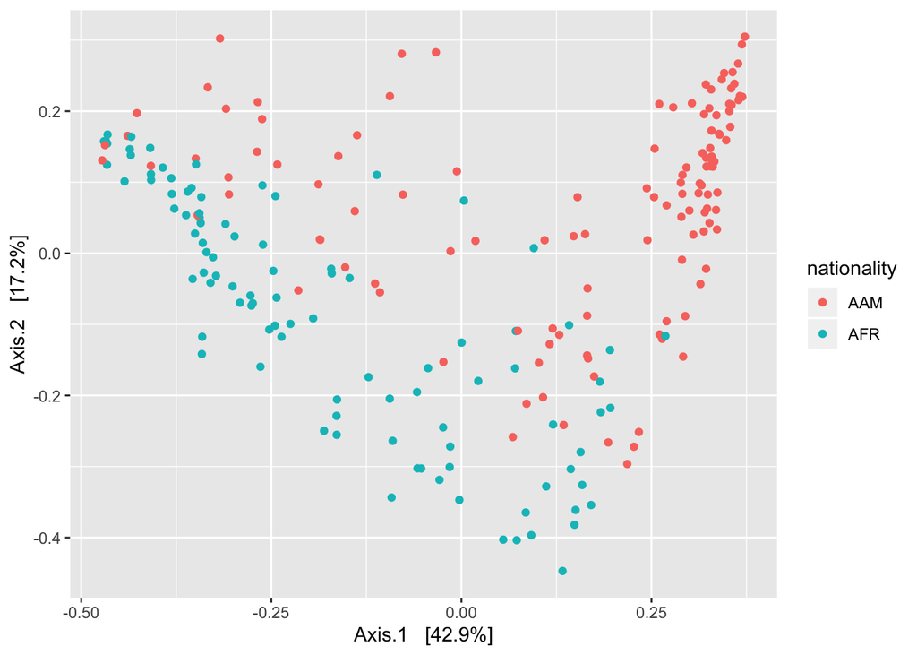

```r
# option 1: Bray Curtis
ord <- ordinate(pseq, method = "PCoA", distance = "bray")
plot_ordination(pseq, ord, color = "nationality")
```

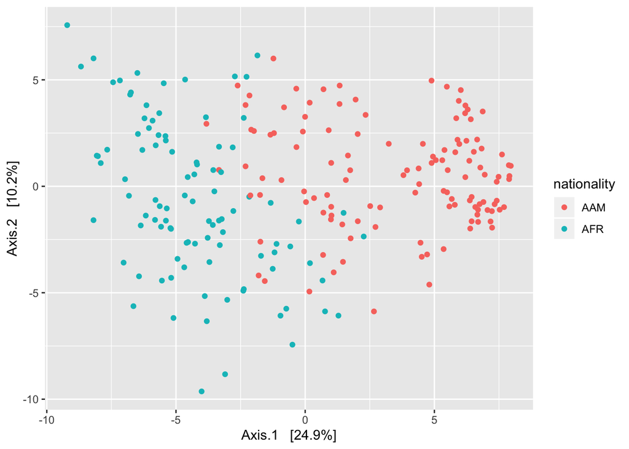

```r
# option 2: Euclidean distance for CLR transformed data
ord <- ordinate(pseq.clr, method = "PCoA", distance = "euclidean")
plot_ordination(pseq, ord, color = "nationality")
```

- **Prevalence** What is the most prevalent genus in the data (tip: microbiome::prevalence and sort)

```r
prevalence(pseq.rel, detection = 0, sort = TRUE) %>%
  kable()
```

|  | x |
| --- | --- |
| Yersinia et rel. | 1.0000000 |
| Weissella et rel. | 1.0000000 |
| Vibrio | 1.0000000 |
| Veillonella | 1.0000000 |
| Uncultured Mollicutes | 1.0000000 |
| Uncultured Clostridiales II | 1.0000000 |
| Uncultured Clostridiales I | 1.0000000 |
| Tannerella et rel. | 1.0000000 |
| Sutterella wadsworthia et rel. | 1.0000000 |
| Subdoligranulum variable at rel. | 1.0000000 |
| Streptococcus mitis et rel. | 1.0000000 |
| Streptococcus intermedius et rel. | 1.0000000 |
| Streptococcus bovis et rel. | 1.0000000 |
| Sporobacter termitidis et rel. | 1.0000000 |
| Ruminococcus obeum et rel. | 1.0000000 |
| Ruminococcus lactaris et rel. | 1.0000000 |
| Ruminococcus gnavus et rel. | 1.0000000 |
| Ruminococcus callidus et rel. | 1.0000000 |
| Ruminococcus bromii et rel. | 1.0000000 |
| Roseburia intestinalis et rel. | 1.0000000 |
| Proteus et rel. | 1.0000000 |
| Propionibacterium | 1.0000000 |
| Prevotella tannerae et rel. | 1.0000000 |
| Prevotella oralis et rel. | 1.0000000 |
| Prevotella melaninogenica et rel. | 1.0000000 |
| Phascolarctobacterium faecium et rel. | 1.0000000 |
| Peptostreptococcus micros et rel. | 1.0000000 |
| Peptococcus niger et rel. | 1.0000000 |
| Parabacteroides distasonis et rel. | 1.0000000 |
| Papillibacter cinnamivorans et rel. | 1.0000000 |

[output cut: 100 more lines]

```r
prevalence(pseq.rel, detection = 0.003, sort = TRUE) %>%
  kable()
```

|  | x |
| --- | --- |
| Oscillospira guillermondii et rel. | 1.0000000 |
| Ruminococcus obeum et rel. | 0.9954955 |
| Faecalibacterium prausnitzii et rel. | 0.9954955 |
| Clostridium symbiosum et rel. | 0.9954955 |
| Sporobacter termitidis et rel. | 0.9594595 |
| Clostridium orbiscindens et rel. | 0.9549550 |
| Bacteroides vulgatus et rel. | 0.9549550 |
| Butyrivibrio crossotus et rel. | 0.9504505 |
| Subdoligranulum variable at rel. | 0.9279279 |
| Clostridium cellulosi et rel. | 0.9099099 |
| Prevotella melaninogenica et rel. | 0.8828829 |
| Dorea formicigenerans et rel. | 0.8063063 |
| Prevotella oralis et rel. | 0.7972973 |
| Allistipes et rel. | 0.7387387 |
| Clostridium sphenoides et rel. | 0.7342342 |
| Bacteroides fragilis et rel. | 0.6531532 |
| Clostridium leptum et rel. | 0.6351351 |
| Parabacteroides distasonis et rel. | 0.6171171 |
| Bryantella formatexigens et rel. | 0.5900901 |
| Coprococcus eutactus et rel. | 0.5810811 |
| Bacteroides ovatus et rel. | 0.5540541 |
| Lachnospira pectinoschiza et rel. | 0.5495495 |
| Uncultured Clostridiales II | 0.4954955 |
| Prevotella tannerae et rel. | 0.4864865 |
| Bacteroides uniformis et rel. | 0.4864865 |
| Akkermansia | 0.4819820 |
| Anaerostipes caccae et rel. | 0.4774775 |
| Bacteroides splachnicus et rel. | 0.4549550 |
| Eubacterium rectale et rel. | 0.4504505 |
| Anaerotruncus colihominis et rel. | 0.4414414 |

[output cut: 100 more lines]

- **Core microbiota** Pick up the core microbiota including taxa that exceed 0.1% relative abundance in over 50% of the samples (prevalence). How many core taxa there are? You can read more about the core microbiota definition in Salonen et al. 2012. Visualize the core microbiota by following the available [examples](https://microbiome.github.io/tutorials/Core.html).

```r
pseq.core <- core(pseq.rel, detection = 0.001, prevalence = 0.5)
# how many taxa are there?
taxa(pseq.core) %>% length()
```

```
## [1] 52
```

```r
# alternative
core_members(pseq.rel, detection = 0.001, prevalence = 0.5) %>% length()
```

```
## [1] 52
```

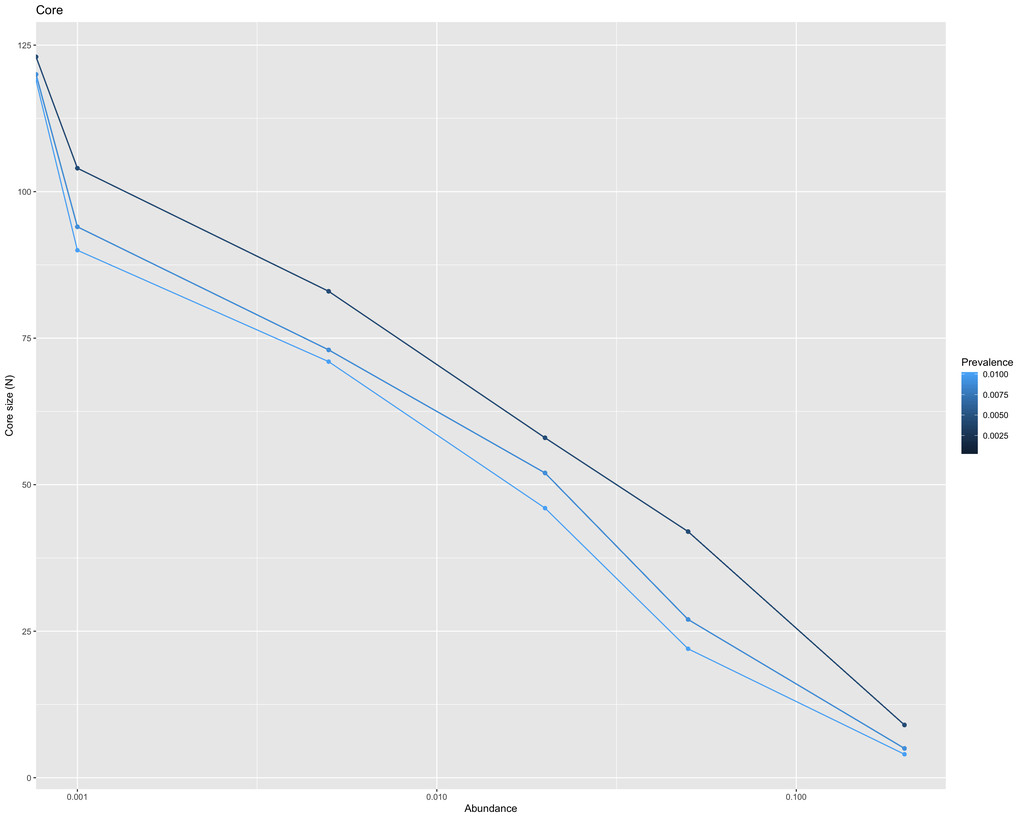

```r
# vizualize core microbiota

# core line plots
detections <- c(0, 0.1, 0.5, 2, 5, 20)/100
prevalences <- seq(0.05, 1, 0.05)
plot_core(pseq.rel, prevalences = prevalences, detections = detections, plot.type = "lineplot")
```

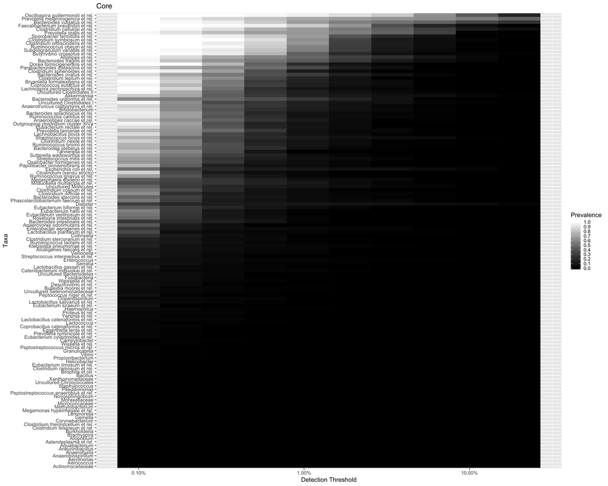

```r
# core heatmaps
prevalences <- seq(0.05, 1, 0.05)
detections <- 10^seq(log10(1e-3), log10(0.2), length = 10)
# define gray color palette
gray <- gray(seq(0, 1, length = 5))

p <- plot_core(
  pseq.rel,
  plot.type = "heatmap",
  colours = gray,
  prevalences = prevalences,
  detections = detections)


print(p)
```

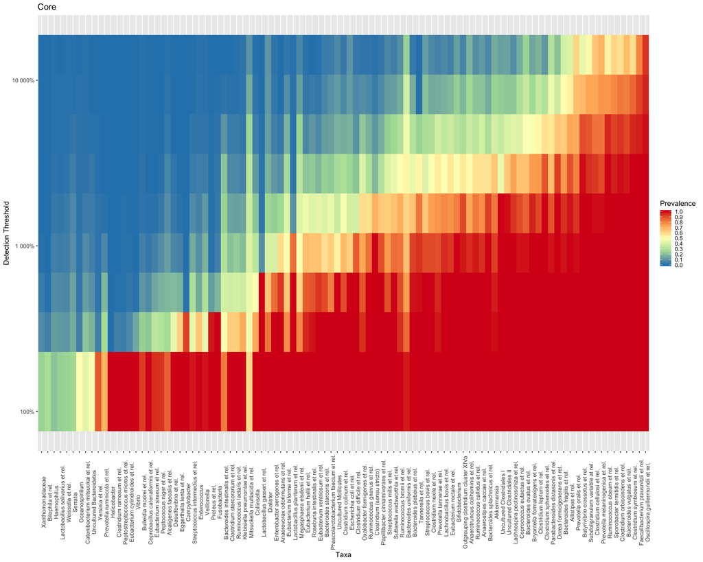

```r
# Core with absolute counts and horizontal view:
# and minimum population prevalence (given as percentage)
detections <- 10^seq(log10(1), log10(max(abundances(pseq))/100), length = 10)
library(RColorBrewer)
p <- plot_core(pseq,
               plot.type = "heatmap",
               prevalences = prevalences,
               detections = detections,
               colours = rev(brewer.pal(5, "Spectral")),
               min.prevalence = .2,
               horizontal = TRUE)
print(p)
```

## Part II: Statistical testing

- **Community-level comparisons** Use [PERMANOVA](https://microbiome.github.io/tutorials/PERMANOVA.html) to investigate whether the community composition differs between two groups of individuals (e.g. males and females, or some other grouping of your choice). You can also include covariates such as age and gender, and see how this affects the results.

```r
# to perform PERMANOVA we need vegan
library(vegan)

# extract relative abundances and meta data
otu.relative <- abundances(pseq.rel)
pseq.meta <- meta(pseq.rel)

# Before we perform PERMANOVA we must test the assumption
# that the multivariate spread between the groups is similar.
dist <- vegdist(t(otu.relative))
# in this specific case the assumption is not met for bmi_group
betadisper(dist, pseq.meta$bmi_group) %>%
  anova() %>%
  kable()
```

|  | Df | Sum Sq | Mean Sq | F value | Pr(>F) |
| --- | --- | --- | --- | --- | --- |
| Groups | 2 | 0.1789275 | 0.0894637 | 7.699571 | 0.0005867 |
| Residuals | 219 | 2.5446297 | 0.0116193 | NA | NA |

```r
# perform PERMANOVA
pm <- adonis(
  t(otu.relative) ~ bmi_group,
  data = pseq.meta,
  permutations = 999,
  method = "bray"
  )

# to obtain the effect size and the F-test p-value:
pm$aov.tab %>% as.data.frame() %>%
  kable()
```

|  | Df | SumsOfSqs | MeanSqs | F.Model | R2 | Pr(>F) |
| --- | --- | --- | --- | --- | --- | --- |
| bmi_group | 2 | 2.260931 | 1.1304655 | 7.167585 | 0.061436 | 0.001 |
| Residuals | 219 | 34.540499 | 0.1577192 | NA | 0.938564 | NA |
| Total | 221 | 36.801430 | NA | NA | 1.000000 | NA |

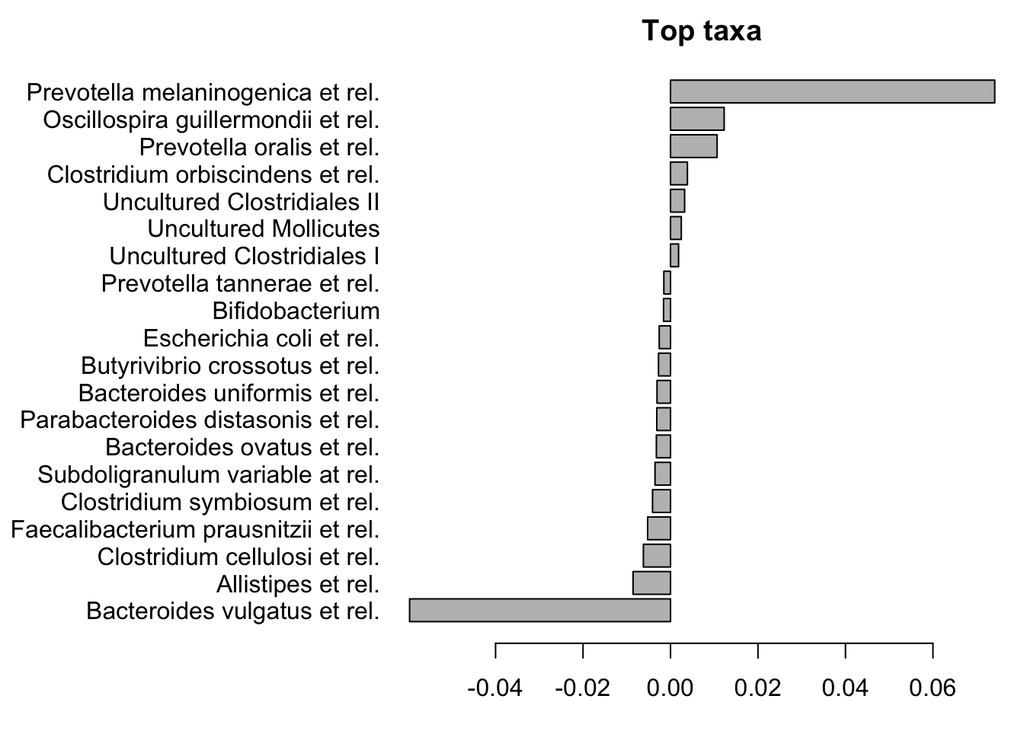

```r
# to investigate the top factors
coef <- coefficients(pm)["bmi_group1", ]

# with base R
top.coef <- coef[rev(order(abs(coef)))[1:20]]
par(mar = c(3, 14, 2, 1))
barplot(sort(top.coef), horiz = T, las = 1, main = "Top taxa")
```

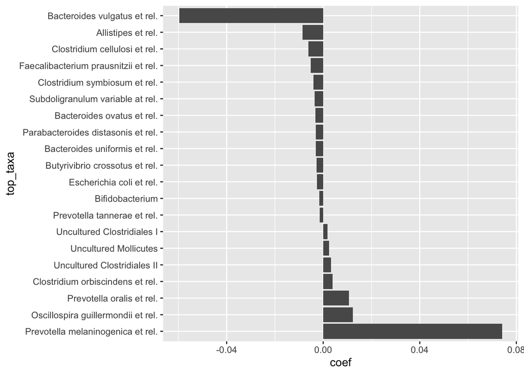

```r
# with ggplot
coef %>% as.data.frame() %>% # convert to dataframe
  rownames_to_column("taxa") %>% # add the rownames as a column for plotting
  select(taxa, coef = ".") %>% # select and rename the columns
  arrange(desc(abs(coef))) %>% # sort by absolute value
  head(20) %>% # pick 20 highest coefficients
  arrange(desc(coef)) %>% # sort by value
  mutate(top_taxa = factor(taxa, levels = taxa)) %>% # for ggplot to keep order we need factor
  ggplot(aes(top_taxa, coef)) + # plot
  geom_bar(stat = "identity") +
  coord_flip()
```

Below I explore whether using a different distance metric as suggested by [Gloor et al. 2017](https://www.frontiersin.org/articles/10.3389/fmicb.2017.02224/full) makes a difference in the interpreations of the results:

```r
# extract relative abundances and meta data
otu.clr <- abundances(pseq.clr)
pseq.meta <- meta(pseq.clr)

# Before we perform PERMANOVA we must test the assumption
# that the multivariate spread between the groups is similar.
dist.ait <- vegdist(t(otu.clr), method = "euclidean")
# in this specific case the assumption is not met for bmi_group
betadisper(dist.ait, pseq.meta$bmi_group) %>%
  anova() %>%
  kable()
```

|  | Df | Sum Sq | Mean Sq | F value | Pr(>F) |
| --- | --- | --- | --- | --- | --- |
| Groups | 2 | 20.49769 | 10.248846 | 3.212052 | 0.0421786 |
| Residuals | 219 | 698.77359 | 3.190747 | NA | NA |

```r
# perform PERMANOVA
pm.ait <- adonis(
  t(otu.clr) ~ bmi_group,
  data = pseq.meta,
  permutations = 999,
  method = "euclidean"
  )

# to obtain the effect size and the F-test p-value:
pm.ait$aov.tab %>% as.data.frame() %>%
  kable()
```

|  | Df | SumsOfSqs | MeanSqs | F.Model | R2 | Pr(>F) |
| --- | --- | --- | --- | --- | --- | --- |
| bmi_group | 2 | 886.8307 | 443.41533 | 4.845104 | 0.0423726 | 0.001 |
| Residuals | 219 | 20042.4899 | 91.51822 | NA | 0.9576274 | NA |
| Total | 221 | 20929.3206 | NA | NA | 1.0000000 | NA |

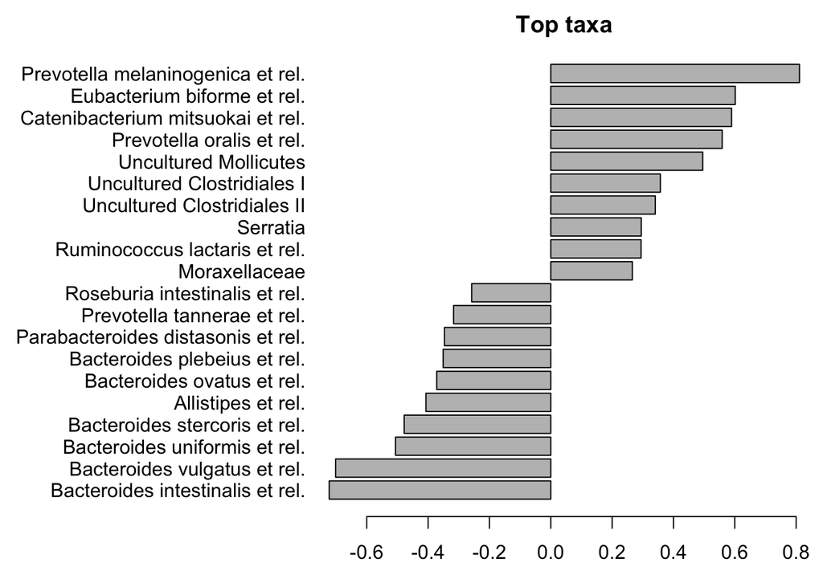

```r
# to investigate the top factors
coef.ait <- coefficients(pm.ait)["bmi_group1", ]

# with base R
top.coef.ait <- coef.ait[rev(order(abs(coef.ait)))[1:20]]
par(mar = c(3, 14, 2, 1))
barplot(sort(top.coef.ait), horiz = T, las = 1, main = "Top taxa")
```

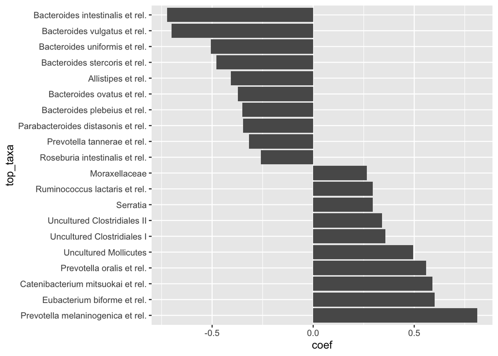

```r
# with ggplot
coef.ait %>% as.data.frame() %>% # convert to dataframe
  rownames_to_column("taxa") %>% # add the rownames as a column for plotting
  select(taxa, coef = ".") %>% # select and rename the columns
  arrange(desc(abs(coef.ait))) %>% # sort by absolute value
  head(20) %>% # pick 20 highest coefficients
  arrange(desc(coef)) %>% # sort by value
  mutate(top_taxa = factor(taxa, levels = taxa)) %>% # for ggplot to keep order we need factor
  ggplot(aes(top_taxa, coef)) + # plot
  geom_bar(stat = "identity") +
  coord_flip()
```

We see that in both cases the conclusions would be similar: The assumptions of similar multivariate spread between groups is violated. The PERMANOVA would suggest that belonging to a different BMI group explains a small portion of variation in the microbiota composition. When it comes to most important genera, there is a clear overlap. However, when using Aitchison distance the differences in importance are less extreme.

- **OTU-level comparisons** Use [DESeq2](https://genomebiology.biomedcentral.com/articles/10.1186/s13059-014-0550-8) to identify which genera are associated with gender differences ([examples on DESeq2](https://microbiome.github.io/tutorials/all.html)). For more explanation on the method, see [DESeq2 R/Bioconductor](http://bioconductor.org/packages/devel/bioc/vignettes/DESeq2/inst/doc/DESeq2.html).

```r
library(DESeq2)
# start by converting phyloseq object to deseq2 format
ds2 <- phyloseq_to_deseq2(pseq, ~nationality)
# Run DeSeq2 analysis (all taxa at once!)
dds <- DESeq(ds2)
```

Compare nationalities based on DESeq2 results. Note that covariates are ignored.

```r
res1 <- results(dds, contrast = c("nationality", "AAM", "AFR"))
kable(head(as.data.frame(res1)))
```

|  | baseMean | log2FoldChange | lfcSE | stat | pvalue | padj |
| --- | --- | --- | --- | --- | --- | --- |
| Actinomycetaceae | 0.0658724 | -0.1190488 | 1.1583688 | -0.1027728 | 0.9181433 | 0.9993115 |
| Aerococcus | 0.0000000 | NA | NA | NA | NA | NA |
| Aeromonas | 0.0121168 | -0.0266292 | 2.9154155 | -0.0091339 | 0.9927123 | 0.9993115 |
| Akkermansia | 111.0129290 | 1.1026126 | 0.2258877 | 4.8812429 | 0.0000011 | 0.0000031 |
| Alcaligenes faecalis et rel. | 6.2077261 | -0.3011501 | 0.2208168 | -1.3638004 | 0.1726304 | 0.2412902 |
| Allistipes et rel. | 268.9729468 | 2.7186362 | 0.1587020 | 17.1304496 | 0.0000000 | 0.0000000 |

MA-plot

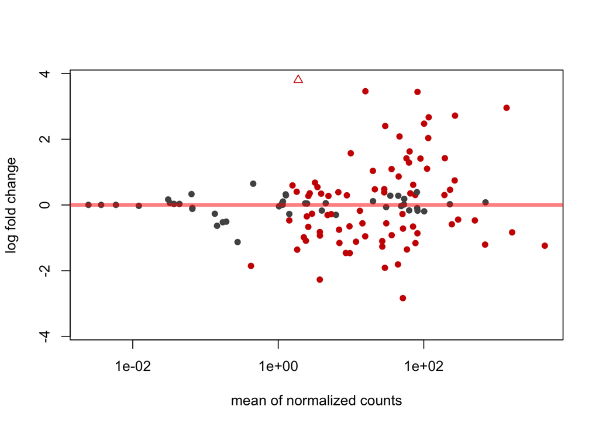

```r
plotMA(res1, cex = 1)
```

Summarize the largest differences as a table:

```r
res <- results(dds)
df <- as.data.frame(res) %>%
  rownames_to_column("taxon") %>%
  filter(padj < 0.05 & abs(log2FoldChange) > 1.5) %>%
  arrange(padj, desc(abs(log2FoldChange))) %>%
  mutate_if(is.numeric, round, 3) %>% # round to 3 decimal places
  kable()
df
```

| taxon | baseMean | log2FoldChange | lfcSE | stat | pvalue | padj |
| --- | --- | --- | --- | --- | --- | --- |
| Bacteroides ovatus et rel. | 116.875 | -2.669 | 0.149 | -17.885 | 0 | 0 |
| Allistipes et rel. | 268.973 | -2.719 | 0.159 | -17.130 | 0 | 0 |
| Bacteroides intestinalis et rel. | 15.757 | -3.461 | 0.208 | -16.675 | 0 | 0 |
| Bacteroides plebeius et rel. | 46.393 | -2.085 | 0.127 | -16.351 | 0 | 0 |
| Bacteroides stercoris et rel. | 29.519 | -2.403 | 0.159 | -15.119 | 0 | 0 |
| Bacteroides vulgatus et rel. | 1374.265 | -2.957 | 0.199 | -14.854 | 0 | 0 |
| Clostridium difficile et rel. | 29.205 | 1.912 | 0.134 | 14.287 | 0 | 0 |
| Parabacteroides distasonis et rel. | 115.211 | -2.036 | 0.147 | -13.816 | 0 | 0 |
| Dialister | 81.981 | -3.442 | 0.287 | -11.984 | 0 | 0 |
| Anaerostipes caccae et rel. | 63.880 | -1.628 | 0.148 | -11.004 | 0 | 0 |
| Bacteroides uniformis et rel. | 101.025 | -2.474 | 0.231 | -10.719 | 0 | 0 |
| Mitsuokella multiacida et rel. | 51.652 | 2.835 | 0.299 | 9.492 | 0 | 0 |
| Clostridium stercorarium et rel. | 9.927 | -1.574 | 0.177 | -8.891 | 0 | 0 |
| Megasphaera elsdenii et rel. | 44.165 | 1.810 | 0.236 | 7.658 | 0 | 0 |
| Uncultured Selenomonadaceae | 1.883 | -4.062 | 0.697 | -5.828 | 0 | 0 |
| Serratia | 3.723 | 2.272 | 0.455 | 4.991 | 0 | 0 |
| Moraxellaceae | 0.422 | 1.854 | 0.480 | 3.861 | 0 | 0 |

- **Role of covariates** Note that including key covariates (diet, medication, age..) may have remarkable influence on data interpretation in the above analyses ([Falony et al. Science 2016](https://science.sciencemag.org/content/352/6285/560.abstract?ijkey=ADV4ZnF4mHYIg&keytype=ref&siteid=sci))
- Experiment with the other available tools in the [microbiome tutorial](https://microbiome.github.io/tutorials/)
- Provide a compact summary of the data and analyses in the form of a reproducible Rmarkdown report. Include only selected summaries and analyses of your choice, and focus on delivering a clear and compact report.